# Spatial Statistics - Introduction

# Task 7: Point Pattern testing

Two `ppp` objects have been created called `p1` and `p2` in your /data folder. Test if they are clustered or regular, and select the right answer. You’ll need to run `quadrat.test` four times, once for each process with each hypothesis.

### Possible Answers

1. p1 is regular, p2 is regular
2. p1 is regular, p2 is clustered
3. p1 is clustered, p2 is clustered #is apparently correct, but i’m not sure I understand why
4. p1 is clustered, p2 is regular

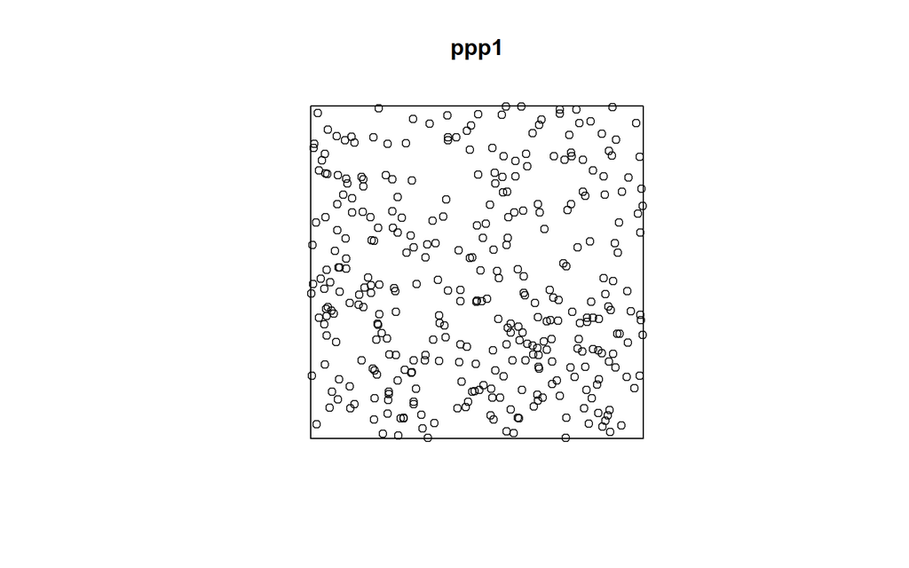

```r
#data: Two `ppp` objects
ppp1 <- readRDS("data/p1.rds")
ppp2 <- readRDS("data/p2.rds")

#plotting
plot(ppp1)
```

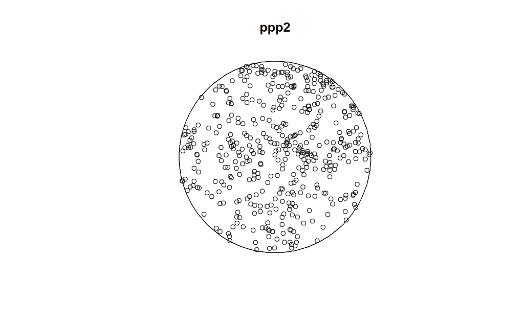

```r
plot(ppp2)
```

```r
#test 4 times
quadrat.test(ppp1, alternative = "clustered") #p-value = 0.02461
```

```
##
##  Chi-squared test of CSR using quadrat counts
##
## data:  ppp1
## X2 = 39.429, df = 24, p-value = 0.02461
## alternative hypothesis: clustered
##
## Quadrats: 5 by 5 grid of tiles
```

```r
quadrat.test(ppp1, alternative = "regular") #p-value = 0.9754
```

```
##
##  Chi-squared test of CSR using quadrat counts
##
## data:  ppp1
## X2 = 39.429, df = 24, p-value = 0.9754
## alternative hypothesis: regular
##
## Quadrats: 5 by 5 grid of tiles
```

```r
quadrat.test(ppp2, alternative = "clustered") #p-value = 0.0006173
```

```
##
##  Chi-squared test of CSR using quadrat counts
##
## data:  ppp2
## X2 = 52.786, df = 24, p-value = 0.0006173
## alternative hypothesis: clustered
##
## Quadrats: 25 tiles (irregular windows)
```

```r
quadrat.test(ppp2, alternative = "regular") #p-value = 0.9994
```

```
##
##  Chi-squared test of CSR using quadrat counts
##
## data:  ppp2
## X2 = 52.786, df = 24, p-value = 0.9994
## alternative hypothesis: regular
##
## Quadrats: 25 tiles (irregular windows)
```